# Data Analysis and Visualization in R - Study Case 1

### Daniela Simancas, Miguel Sandim, Paula Fortuna

### TUM - Data Analysis and Visualization in R

# 1. Read the data.

```r
expression <- fread("expression.txt")
gene <- fread("gene.txt")
genotype <- fread("genotype.txt")
growth <- fread("growth.txt")
marker <- fread("marker.txt")
```

# 2. Tidy the data

```r
genotype <- genotype %>% gather("marker", "type", starts_with("mrk_"))
head(genotype)
```

```
##    strain marker         type
## 1 seg_01B  mrk_1   Lab strain
## 2 seg_01C  mrk_1 Wild isolate
## 3 seg_01D  mrk_1   Lab strain
## 4 seg_02B  mrk_1   Lab strain
## 5 seg_02C  mrk_1 Wild isolate
## 6 seg_02D  mrk_1   Lab strain
```

```r
expression <- expression %>% mutate(gene = rownames(expression)) %>% gather("stuff", "expression", starts_with("Y")) %>% separate(col = stuff, into = c("environment", "strain"), sep="\\-")
head(expression)
```

```
##   gene environment  strain  expression
## 1    1         YPD seg_01B -2.02576611
## 2    2         YPD seg_01B -2.02716467
## 3    3         YPD seg_01B -0.44516559
## 4    4         YPD seg_01B  1.05709276
## 5    5         YPD seg_01B -2.02912397
## 6    6         YPD seg_01B -0.05015662
```

```r
growth <- growth %>% gather("environment", "growth", starts_with("Y"))
head(growth)
```

```
##    strain environment   growth
## 1 seg_01B         YPD 12.60399
## 2 seg_01C         YPD 10.79114
## 3 seg_01D         YPD 12.81727
## 4 seg_02B         YPD 10.29921
## 5 seg_02C         YPD 11.13278
## 6 seg_02D         YPD 13.91084
```

# 3. Data pre-processing

```r
genotype_type <- genotype %>% group_by(strain) %>% summarise(NLabStrain = table(type)[["Lab strain"]], NWildIsolate = table(type)[["Wild isolate"]])
head(genotype_type)
```

```
## # A tibble: 6 × 3
##    strain NLabStrain NWildIsolate
##     <chr>      <int>        <int>
## 1 seg_01B        461          539
## 2 seg_01C        497          503
## 3 seg_01D        526          474
## 4 seg_02B        507          493
## 5 seg_02C        500          500
## 6 seg_02D        486          514
```

```r
growth <- left_join(growth, genotype_type, by = "strain") %>% gather("type", "count", NLabStrain, NWildIsolate)
head(growth)
```

```
##    strain environment   growth       type count
## 1 seg_01B         YPD 12.60399 NLabStrain   461
## 2 seg_01C         YPD 10.79114 NLabStrain   497
## 3 seg_01D         YPD 12.81727 NLabStrain   526
## 4 seg_02B         YPD 10.29921 NLabStrain   507
## 5 seg_02C         YPD 11.13278 NLabStrain   500
## 6 seg_02D         YPD 13.91084 NLabStrain   486
```

# 4. Does the genotype also show differences in other media?

In order to analyze the growth differences in the several environments, we plotted the growth of the several yeast strains according to number of markers belonging to the Lab Strains and the Wild Isolates.

We concluded that the presence of markers belonging to Lab Strains and Wild Isolates doesn’t affect the growth. However, it’s ths environment itself that affects this variable (e.g. in YPD_Rapa and YPE the growth is clearly lower than the other environments, independently of the number of markers from each type).

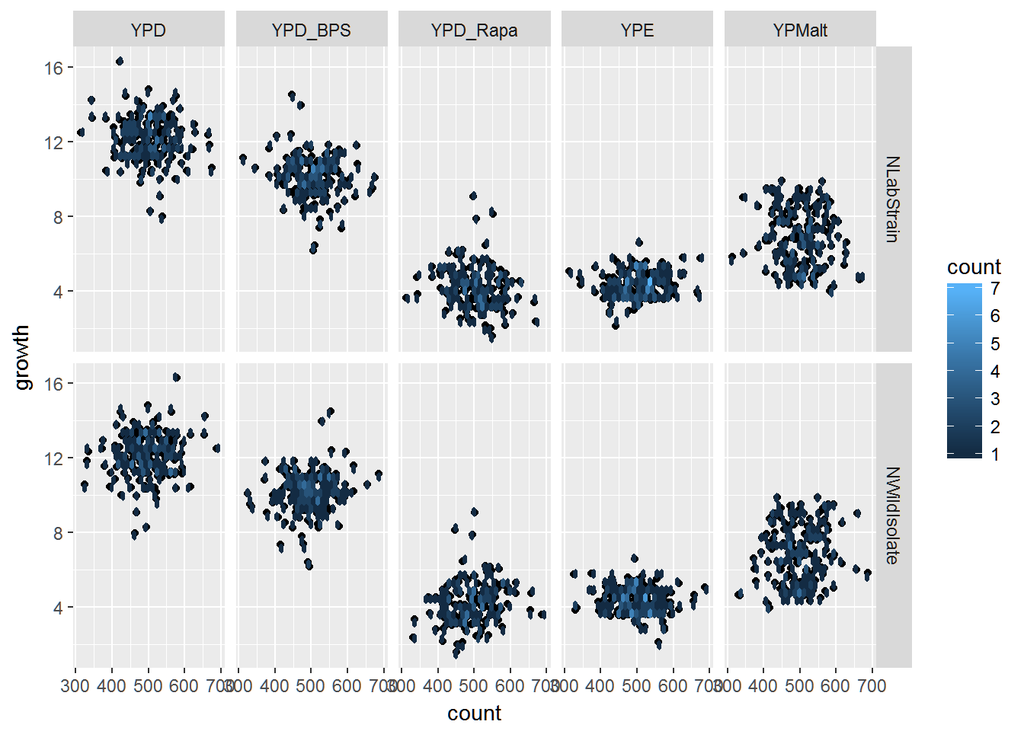

```r
ggplot(growth, aes(count, growth)) +
  geom_point() + geom_hex() +
  facet_grid(type~environment)
```

We then plotted the genes with more expression (among all the strains) in the several environments. We concluded that the genes 3080, 3266 1477 and 1511 are the ones that expressed more in all of the environments.

```r
mean_expression <- expression %>% group_by(environment, gene) %>% summarise(mean_exp = mean(expression)) %>% arrange(environment, desc(mean_exp)) %>% group_by(environment) %>% top_n(n = 10)
```

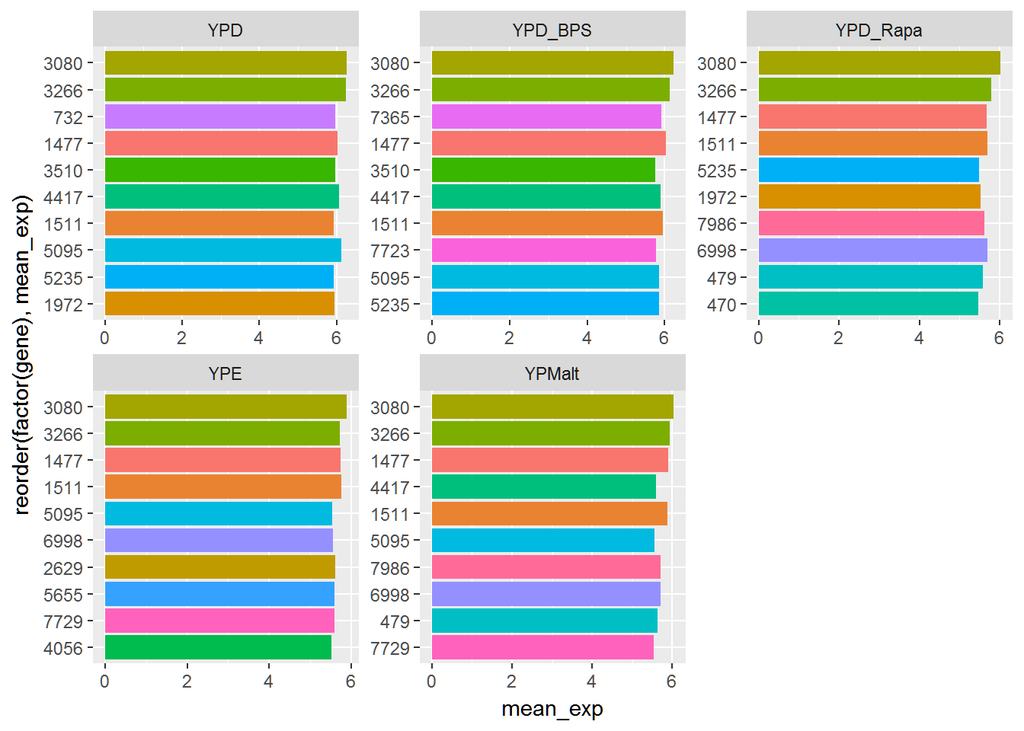

```r
ggplot(mean_expression, aes(x = reorder(factor(gene), mean_exp), y = mean_exp, fill = gene)) +
  geom_bar(stat = "identity") +
  coord_flip() +
  #xlim(5,7) +
  #scale_x_continuous(limits = c(5, 7)) +
  facet_wrap(~environment, scales="free") +
  theme(legend.position="none")
```

We match for each marker the respective gene, but then we found out that we only had a very small amount of genes that were marked, and our featuring genes were not contemplated. This way, the chart we ploted was always empty.

In order to solve this, our goal (which we didn’t finish) was to try to find the nearest marker for every gene (so we could have information of the markers for the genes we are interested in) This way we could identify the type (lab strain or wild isolate).